# 04 - Exploratory Data Analisis - CodeBook

### Facets

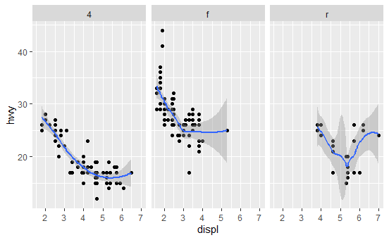

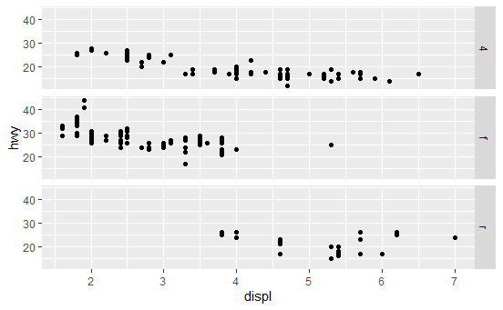

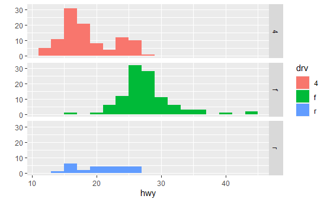

### calc direct in data

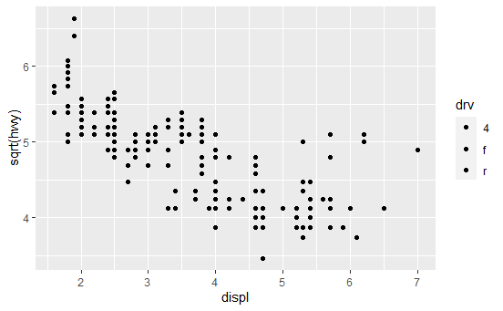

## plot with layers

### First plot

### add smooth

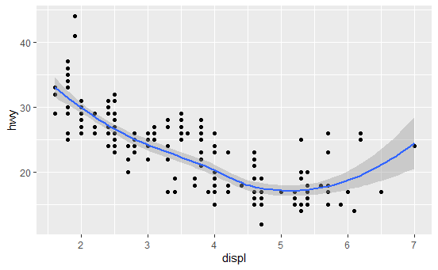

### Facets

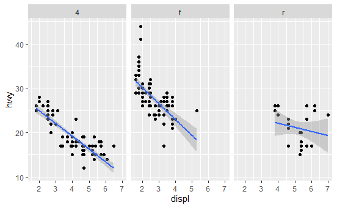

### Annotation

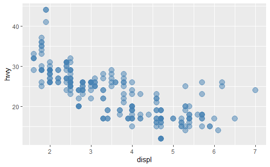

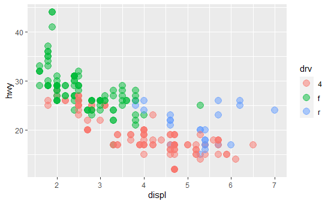

### Modifying Labels

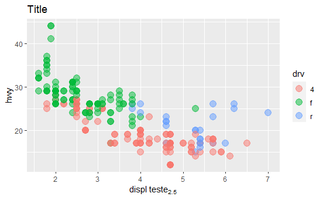

### Customizing the Smooth + rug

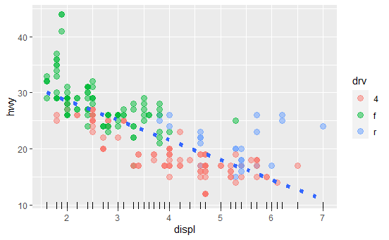

# Changing the Theme

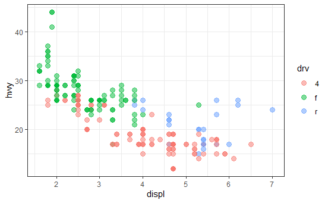

### Notes about Axis Limits

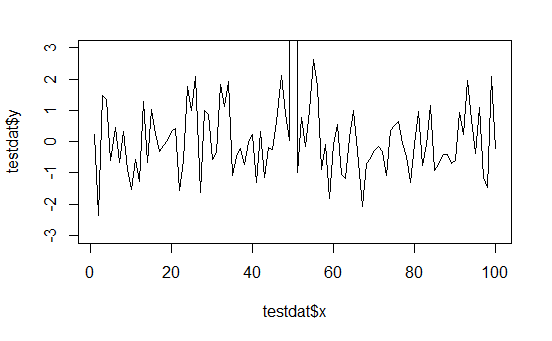

continuos

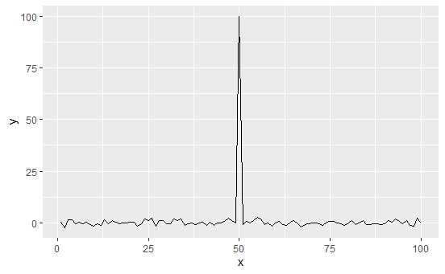

continuos **missing outlier in 50**

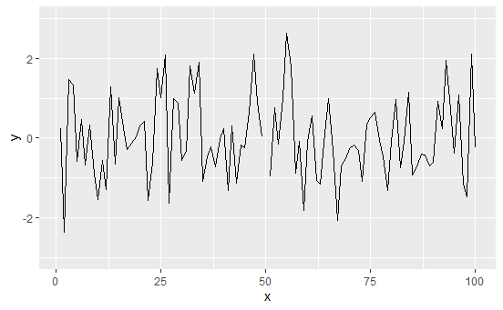

continuos **to include outlier

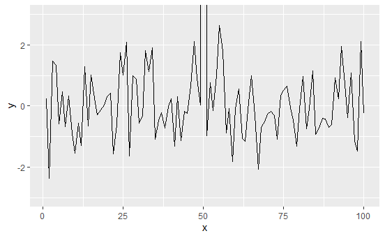

### Multiple panels, change font

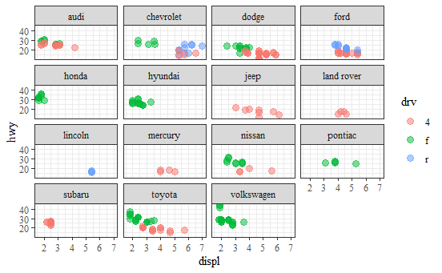

# week 3 - Clustering

### hClust

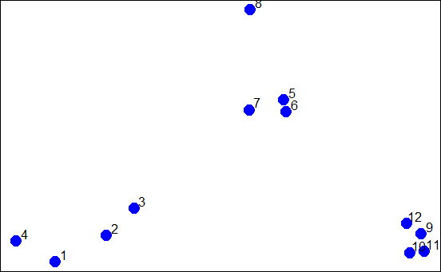

```r
set.seed(1234)
par(mar = c(0, 0, 0, 0))
x <- rnorm(12, mean = rep(1:3, each = 4), sd = 0.2)
y <- rnorm(12, mean = rep(c(1, 2, 1), each = 4), sd = 0.2)

df <- data.frame(x = x, y=y)

plot(df$x, df$y, col = "blue", pch = 19, cex = 2)
   text(x + 0.05, y + 0.05, labels = as.character(1:12))
```

continuing

```r
dist(df)
```

```
            1          2          3          4          5          6
2  0.34120511
3  0.57493739 0.24102750
4  0.26381786 0.52578819 0.71861759
5  1.69424700 1.35818182 1.11952883 1.80666768
6  1.65812902 1.31960442 1.08338841 1.78081321 0.08150268
7  1.49823399 1.16620981 0.92568723 1.60131659 0.21110433 0.21666557
8  1.99149025 1.69093111 1.45648906 2.02849490 0.61704200 0.69791931
9  2.13629539 1.83167669 1.67835968 2.35675598 1.18349654 1.11500116
10 2.06419586 1.76999236 1.63109790 2.29239480 1.23847877 1.16550201
11 2.14702468 1.85183204 1.71074417 2.37461984 1.28153948 1.21077373
12 2.05664233 1.74662555 1.58658782 2.27232243 1.07700974 1.00777231
            7          8          9         10         11
2
3
4
5
6
7
8  0.65062566
9  1.28582631 1.76460709
10 1.32063059 1.83517785 0.14090406
11 1.37369662 1.86999431 0.11624471 0.08317570
12 1.17740375 1.66223814 0.10848966 0.19128645 0.20802789
```

continuing

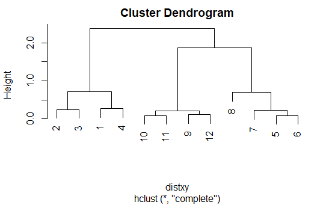

just repeting

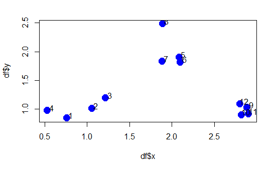

```r
plot(df$x, df$y, col = "blue", pch = 19, cex = 2)
   text(x + 0.05, y + 0.05, labels = as.character(1:12))
```

### Heatmap

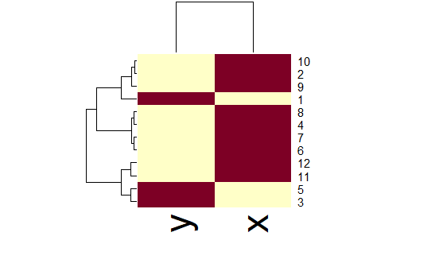

```r
set.seed(1234)
x <- rnorm(12, mean = rep(1:3, each = 4), sd = 0.2)
y <- rnorm(12, mean = rep(c(1, 2, 1), each = 4), sd = 0.2)
dataFrame <- data.frame(x = x, y = y)

set.seed(143)
dataMatrix <- as.matrix(dataFrame)[sample(1:12), ]
heatmap(dataMatrix)
```

```r
NA
NA
```

### k-means

```r
names(kmeansObj)
```

```
[1] "cluster"      "centers"      "totss"        "withinss"
[5] "tot.withinss" "betweenss"    "size"         "iter"
[9] "ifault"
```

continuing

```r
kmeansObj$cluster
```

```
 [1] 3 3 3 3 2 2 2 2 1 1 1 1
```

continuing

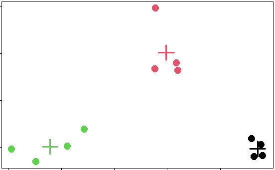

```r
par(mar=rep(0.2,4))
plot(x,y,col=kmeansObj$cluster,pch=19,cex=2)
points(kmeansObj$centers,col=1:3,pch=3,cex=3,lwd=3)
```

### Heatmaps order by kmeans

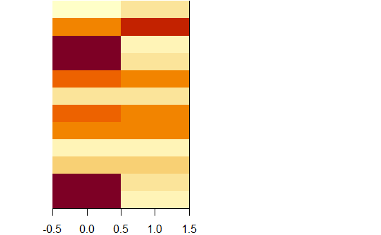

```r
dataMatrix <- as.matrix(dataFrame)[sample(1:12),]
kmeansObj <- kmeans(dataMatrix,centers=3)
par(mfrow=c(1,2), mar = c(2, 4, 0.1, 0.1))
image(t(dataMatrix)[,nrow(dataMatrix):1],yaxt="n")
image(t(dataMatrix)[,order(kmeansObj$cluster)],yaxt="n")
```

[output not shown]

## Dimension Reduction

### Matrix data

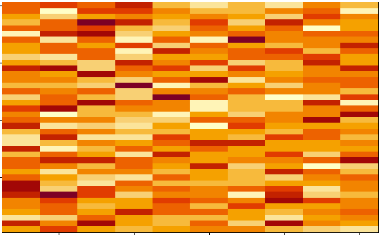

```r
set.seed(12345)
par(mar = rep(0.2, 4))
dataMatrix <- matrix(rnorm(400), nrow = 40)
image(1:10, 1:40, t(dataMatrix)[, nrow(dataMatrix):1])
```

### Cluster the data

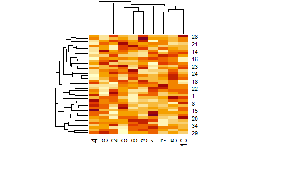

```r
par(mar = rep(0.2, 4))
heatmap(dataMatrix)
```

### Add pattern

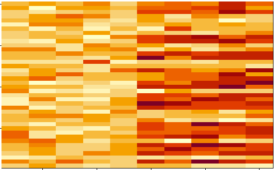

continuing

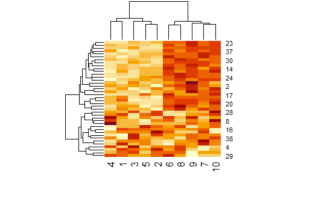

```r
par(mar = rep(0.2, 4))
heatmap(dataMatrix)
```

### Patterns in rows and collumns

```r
hh <- hclust(dist(dataMatrix))
dataMatrixOrdered <- dataMatrix[hh$order, ]
par(mfrow = c(1, 3))
image(t(dataMatrixOrdered)[, nrow(dataMatrixOrdered):1])
plot(rowMeans(dataMatrixOrdered), 40:1, , xlab = "Row Mean", ylab = "Row", pch = 19)
```

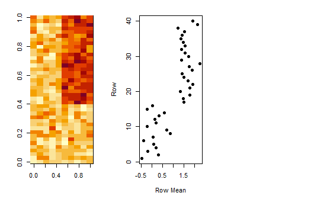

```r
plot(colMeans(dataMatrixOrdered), xlab = "Column", ylab = "Column Mean", pch = 19)
```

[output not shown]

### impute k-value in place of NA missing values

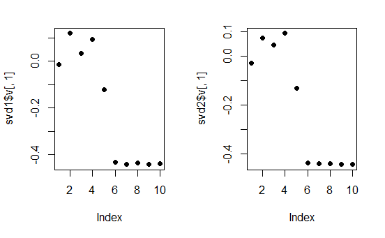

### Reduce qualit image

```r
# problem with load - I load direct from RStudio
#load("./data/face.rda")

svd1 <- svd(scale(faceData))
## Note that %*% is matrix multiplication

# Here svd1$d[1] is a constant
approx1 <- svd1$u[, 1] %*% t(svd1$v[, 1]) * svd1$d[1]

# In these examples we need to make the diagonal matrix out of d
approx5 <- svd1$u[, 1:5] %*% diag(svd1$d[1:5]) %*% t(svd1$v[, 1:5])
approx10 <- svd1$u[, 1:10] %*% diag(svd1$d[1:10]) %*% t(svd1$v[, 1:10])

#graph
par(mfrow = c(2, 2))
image(t(approx1)[, nrow(approx1):1], main = "aprox1")
image(t(approx5)[, nrow(approx5):1], main = "aprox5")
```

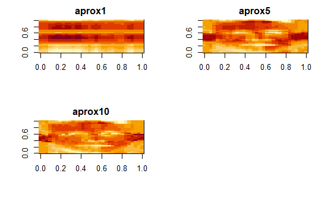

```r
image(t(approx10)[, nrow(approx10):1], main = "aprox10")
image(t(faceData)[, nrow(faceData):1], main = "original") ## Original data
```

[output not shown]

# Plotting and Color

### ColorRamp

```r
pal(seq(0, 1, len = 10))
```

```
           [,1] [,2]      [,3]
 [1,] 255.00000    0   0.00000
 [2,] 226.66667    0  28.33333
 [3,] 198.33333    0  56.66667
 [4,] 170.00000    0  85.00000
 [5,] 141.66667    0 113.33333
 [6,] 113.33333    0 141.66667
 [7,]  85.00000    0 170.00000
 [8,]  56.66667    0 198.33333
 [9,]  28.33333    0 226.66667
[10,]   0.00000    0 255.00000
```

### colorRampPalette

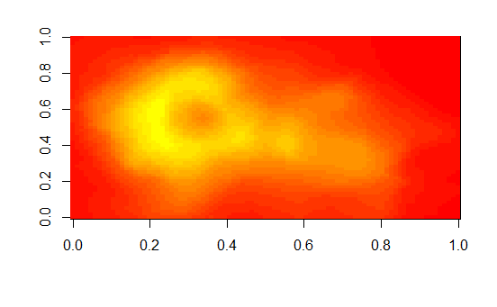

### RColorBrewer Package

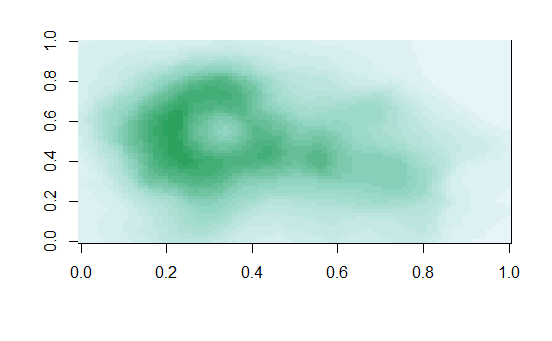

### RColorBrewer and colorRampPalette

```r
 library(RColorBrewer)
 cols <- brewer.pal(3, "BuGn")
 cols
```

```
[1] "#E5F5F9" "#99D8C9" "#2CA25F"
```

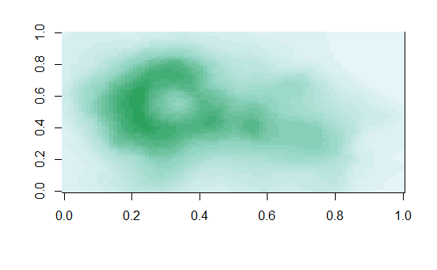

```r
#[1] "#E5F5F9" "#99D8C9" "#2CA25F"
 pal <- colorRampPalette(cols)
 image(volcano, col = pal(20))
```

comparing

```r
 library(RColorBrewer)
 cols <- brewer.pal(3, "BuGn")
 cols
```

```
[1] "#E5F5F9" "#99D8C9" "#2CA25F"
```

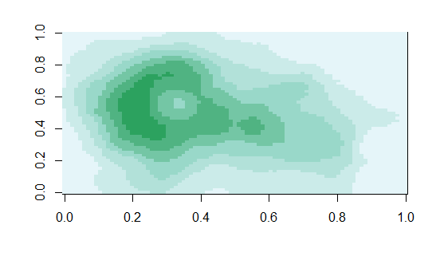

```r
#[1] "#E5F5F9" "#99D8C9" "#2CA25F"
 pal <- colorRampPalette(cols)
 image(volcano, col = pal(7))
```

comparing

```r
 library(RColorBrewer)
 cols <- brewer.pal(7, "BuGn")
 cols
```

```
[1] "#EDF8FB" "#CCECE6" "#99D8C9" "#66C2A4" "#41AE76" "#238B45"
[7] "#005824"
```

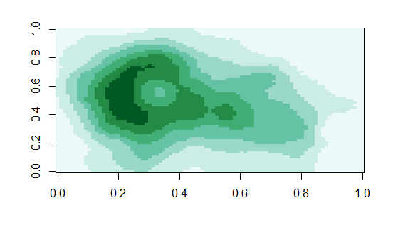

```r
#[1] "#E5F5F9" "#99D8C9" "#2CA25F"
 pal <- colorRampPalette(cols)
 image(volcano, col = pal(7))
```

### smoothScatter function

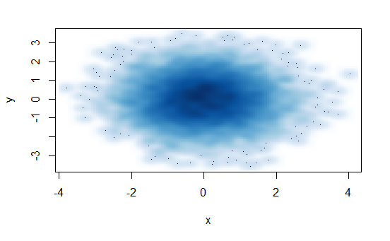

```r
x <- rnorm(10000)
y <- rnorm(10000)
smoothScatter(x,y)
```

### Scatterplot with Transparency

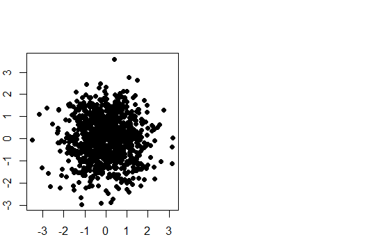

```r
x <- rnorm(1000)
y <- rnorm(1000)
par(mfrow = c(1, 2) , mar = c(2, 2, 2, 1), oma = c(0, 0, 2, 0))
plot(x, y, pch = 19)
plot(x, y, pch = 19, col = rgb(0,0,0,0.2)) # put 0.2 to alpha
```

[output not shown]

# swirl

```r
abline(h=0.1,col="blue")
```

```
Error in int_abline(a = a, b = b, h = h, v = v, untf = untf, ...) :
  plot.new has not been called yet
```

### good heatmap

```r
data("mtcars")
mt <- as.matrix(mtcars[,c(1:7)])
mt
```

```
                     mpg cyl  disp  hp drat    wt  qsec
Mazda RX4           21.0   6 160.0 110 3.90 2.620 16.46
Mazda RX4 Wag       21.0   6 160.0 110 3.90 2.875 17.02
Datsun 710          22.8   4 108.0  93 3.85 2.320 18.61
Hornet 4 Drive      21.4   6 258.0 110 3.08 3.215 19.44
Hornet Sportabout   18.7   8 360.0 175 3.15 3.440 17.02
Valiant             18.1   6 225.0 105 2.76 3.460 20.22
Duster 360          14.3   8 360.0 245 3.21 3.570 15.84
Merc 240D           24.4   4 146.7  62 3.69 3.190 20.00
Merc 230            22.8   4 140.8  95 3.92 3.150 22.90
Merc 280            19.2   6 167.6 123 3.92 3.440 18.30
Merc 280C           17.8   6 167.6 123 3.92 3.440 18.90
Merc 450SE          16.4   8 275.8 180 3.07 4.070 17.40
Merc 450SL          17.3   8 275.8 180 3.07 3.730 17.60
Merc 450SLC         15.2   8 275.8 180 3.07 3.780 18.00
Cadillac Fleetwood  10.4   8 472.0 205 2.93 5.250 17.98
Lincoln Continental 10.4   8 460.0 215 3.00 5.424 17.82
Chrysler Imperial   14.7   8 440.0 230 3.23 5.345 17.42
Fiat 128            32.4   4  78.7  66 4.08 2.200 19.47
Honda Civic         30.4   4  75.7  52 4.93 1.615 18.52
Toyota Corolla      33.9   4  71.1  65 4.22 1.835 19.90
Toyota Corona       21.5   4 120.1  97 3.70 2.465 20.01
Dodge Challenger    15.5   8 318.0 150 2.76 3.520 16.87
AMC Javelin         15.2   8 304.0 150 3.15 3.435 17.30
Camaro Z28          13.3   8 350.0 245 3.73 3.840 15.41
Pontiac Firebird    19.2   8 400.0 175 3.08 3.845 17.05
Fiat X1-9           27.3   4  79.0  66 4.08 1.935 18.90
Porsche 914-2       26.0   4 120.3  91 4.43 2.140 16.70
Lotus Europa        30.4   4  95.1 113 3.77 1.513 16.90
Ford Pantera L      15.8   8 351.0 264 4.22 3.170 14.50
Ferrari Dino        19.7   6 145.0 175 3.62 2.770 15.50
Maserati Bora       15.0   8 301.0 335 3.54 3.570 14.60
Volvo 142E          21.4   4 121.0 109 4.11 2.780 18.60
```

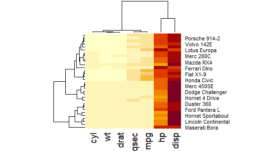

```r
#                   mpg cyl  disp  hp drat    wt
# Dodge Challenger 15.5   8 318.0 150 2.76 3.520
# AMC Javelin      15.2   8 304.0 150 3.15 3.435
# Camaro Z28       13.3   8 350.0 245 3.73 3.840
# Pontiac Firebird 19.2   8 400.0 175 3.08 3.845
# Fiat X1-9        27.3   4  79.0  66 4.08 1.935
# Porsche 914-2    26.0   4 120.3  91 4.43 2.140
# Lotus Europa     30.4   4  95.1 113 3.77 1.513
# Ford Pantera L   15.8   8 351.0 264 4.22 3.170
# Ferrari Dino     19.7   6 145.0 175 3.62 2.770
# Maserati Bora    15.0   8 301.0 335 3.54 3.570
# Volvo 142E       21.4   4 121.0 109 4.11 2.780
# Legend
# [, 1] mpg Miles/(US) gallon
# [, 2] cyl Number of cylinders
# [, 3] disp    Displacement (cu.in.)
# [, 4] hp  Gross horsepower
# [, 5] drat    Rear axle ratio
# [, 6] wt  Weight (1000 lbs)

heatmap(mt)
```

```r
NA
NA
```

# week 4

### data samsungData

### Plotting average acceleration for first subject

### Clustering based just on average acceleration

### Plotting max acceleration for the first subject

### Clustering based on maximum acceleration

### Singular Value Decomposition

### Find maximum contributor

### New clustering with maximum contributer

# Air Pollution Case Study

## complete script

## following with video

### Read

```r
#getwd()
#setwd("./data/") need correct
setwd("D:/Dados_Denis/Academico/Data Science/Projetos/studyDataScienceCoursera/data")
```

```
The working directory was changed to D:/Dados_Denis/Academico/Data Science/Projetos/studyDataScienceCoursera/data inside a notebook chunk. The working directory will be reset when the chunk is finished running. Use the knitr root.dir option in the setup chunk to change the working directory for note…
```

```r
# need extract header apart
pm0 <- read.table("RD_501_88101_1999-0.txt",
                  comment.char = "#",
                  header = F,
                  sep = "|",
                  na.strings = "",
                  )
```

```r
head(pm0)
```

|  | V1 | V2 | V3 | V4 | V5 | V6 | V7 | V8 | V9 | V10 | V11 | V12 | V13 | V14 | V15 | V16 | V17 | V18 | V19 | V20 | V21 | V22 | V23 | V24 | V25 | V26 | V27 | V28 |
| --- | --- | --- | --- | --- | --- | --- | --- | --- | --- | --- | --- | --- | --- | --- | --- | --- | --- | --- | --- | --- | --- | --- | --- | --- | --- | --- | --- | --- |
| 1 | RD | I | 1 | 27 | 1 | 88101 | 1 | 7 | 105 | 120 | 19990103 | 00:00 | NA | AS | 3 | NA | NA | NA | NA | NA | NA | NA | NA | NA | NA | NA | NA | NA |
| 2 | RD | I | 1 | 27 | 1 | 88101 | 1 | 7 | 105 | 120 | 19990106 | 00:00 | NA | AS | 3 | NA | NA | NA | NA | NA | NA | NA | NA | NA | NA | NA | NA | NA |
| 3 | RD | I | 1 | 27 | 1 | 88101 | 1 | 7 | 105 | 120 | 19990109 | 00:00 | NA | AS | 3 | NA | NA | NA | NA | NA | NA | NA | NA | NA | NA | NA | NA | NA |
| 4 | RD | I | 1 | 27 | 1 | 88101 | 1 | 7 | 105 | 120 | 19990112 | 00:00 | 8.841 | NA | 3 | NA | NA | NA | NA | NA | NA | NA | NA | NA | NA | NA | NA | NA |
| 5 | RD | I | 1 | 27 | 1 | 88101 | 1 | 7 | 105 | 120 | 19990115 | 00:00 | 14.920 | NA | 3 | NA | NA | NA | NA | NA | NA | NA | NA | NA | NA | NA | NA | NA |
| 6 | RD | I | 1 | 27 | 1 | 88101 | 1 | 7 | 105 | 120 | 19990118 | 00:00 | 3.878 | NA | 3 | NA | NA | NA | NA | NA | NA | NA | NA | NA | NA | NA | NA | NA |

```r
setwd("D:/Dados_Denis/Academico/Data Science/Projetos/studyDataScienceCoursera/data")
```

```
The working directory was changed to D:/Dados_Denis/Academico/Data Science/Projetos/studyDataScienceCoursera/data inside a notebook chunk. The working directory will be reset when the chunk is finished running. Use the knitr root.dir option in the setup chunk to change the working directory for note…
```

```r
cnames <- readLines("RD_501_88101_1999-0.txt",1)
cnames
```

```
[1] "# RD|Action Code|State Code|County Code|Site ID|Parameter|POC|Sample Duration|Unit|Method|Date|Start Time|Sample Value|Null Data Code|Sampling Frequency|Monitor Protocol (MP) ID|Qualifier - 1|Qualifier - 2|Qualifier - 3|Qualifier - 4|Qualifier - 5|Qualifier - 6|Qualifier - 7|Qualifier - 8|Quali…
```

```r
cnames <- strsplit(cnames, "|", fixed = T)
cnames
```

```
[[1]]
 [1] "# RD"
 [2] "Action Code"
 [3] "State Code"
 [4] "County Code"
 [5] "Site ID"
 [6] "Parameter"
 [7] "POC"
 [8] "Sample Duration"
 [9] "Unit"
[10] "Method"
[11] "Date"
[12] "Start Time"
[13] "Sample Value"
[14] "Null Data Code"
[15] "Sampling Frequency"
[16] "Monitor Protocol (MP) ID"
[17] "Qualifier - 1"
[18] "Qualifier - 2"
[19] "Qualifier - 3"
[20] "Qualifier - 4"
[21] "Qualifier - 5"
[22] "Qualifier - 6"
[23] "Qualifier - 7"
[24] "Qualifier - 8"
[25] "Qualifier - 9"
[26] "Qualifier - 10"
[27] "Alternate Method Detectable Limit"
[28] "Uncertainty"
```

### make.names() - Turn valid column names

```r
names(pm0) <- make.names(cnames[[1]])
head(pm0)
```

|  | X..RD | Action.Code | State.Code | County.Code | Site.ID | Parameter | POC | Sample.Duration | Unit | Method | Date | Start.Time | Sample.Value | Null.Data.Code | Sampling.Frequency | Monitor.Protocol..MP..ID | Qualifier...1 | Qualifier...2 | Qualifier...3 | Qualifier...4 | Qualifier...5 | Qualifier...6 | Qualifier...7 | Qualifier...8 | Qualifier...9 | Qualifier...10 | Alternate.Method.Detectable.Limit | Uncertainty |
| --- | --- | --- | --- | --- | --- | --- | --- | --- | --- | --- | --- | --- | --- | --- | --- | --- | --- | --- | --- | --- | --- | --- | --- | --- | --- | --- | --- | --- |
| 1 | RD | I | 1 | 27 | 1 | 88101 | 1 | 7 | 105 | 120 | 19990103 | 00:00 | NA | AS | 3 | NA | NA | NA | NA | NA | NA | NA | NA | NA | NA | NA | NA | NA |
| 2 | RD | I | 1 | 27 | 1 | 88101 | 1 | 7 | 105 | 120 | 19990106 | 00:00 | NA | AS | 3 | NA | NA | NA | NA | NA | NA | NA | NA | NA | NA | NA | NA | NA |
| 3 | RD | I | 1 | 27 | 1 | 88101 | 1 | 7 | 105 | 120 | 19990109 | 00:00 | NA | AS | 3 | NA | NA | NA | NA | NA | NA | NA | NA | NA | NA | NA | NA | NA |
| 4 | RD | I | 1 | 27 | 1 | 88101 | 1 | 7 | 105 | 120 | 19990112 | 00:00 | 8.841 | NA | 3 | NA | NA | NA | NA | NA | NA | NA | NA | NA | NA | NA | NA | NA |
| 5 | RD | I | 1 | 27 | 1 | 88101 | 1 | 7 | 105 | 120 | 19990115 | 00:00 | 14.920 | NA | 3 | NA | NA | NA | NA | NA | NA | NA | NA | NA | NA | NA | NA | NA |
| 6 | RD | I | 1 | 27 | 1 | 88101 | 1 | 7 | 105 | 120 | 19990118 | 00:00 | 3.878 | NA | 3 | NA | NA | NA | NA | NA | NA | NA | NA | NA | NA | NA | NA | NA |

### continuous

```r
x0 <- pm0$Sample.Value
str(x0)
```

```
 num [1:117421] NA NA NA 8.84 14.92 ...
```

```r
summary(x0)
```

```
   Min. 1st Qu.  Median    Mean 3rd Qu.    Max.    NA's
   0.00    7.20   11.50   13.74   17.90  157.10   13217
```

**calc % of NA** 11% look the data

```r
mean(is.na(x0))
```

```
[1] 0.1125608
```

### read data of 2012

the same of 1999

```r
setwd("D:/Dados_Denis/Academico/Data Science/Projetos/studyDataScienceCoursera/data")
```

```
The working directory was changed to D:/Dados_Denis/Academico/Data Science/Projetos/studyDataScienceCoursera/data inside a notebook chunk. The working directory will be reset when the chunk is finished running. Use the knitr root.dir option in the setup chunk to change the working directory for note…
```

```r
# need extract header apart
pm1 <- read.table("RD_501_88101_2012-0.txt",
                  comment.char = "#",
                  header = F,
                  sep = "|",
                  na.strings = "",
                  )
cnames <- readLines("RD_501_88101_2012-0.txt",1)
cnames <- strsplit(cnames, "|", fixed = T)
names(pm1) <- make.names(cnames[[1]])
head(pm1)
```

|  | X..RD | Action.Code | State.Code | County.Code | Site.ID | Parameter | POC | Sample.Duration | Unit | Method | Date | Start.Time | Sample.Value | Null.Data.Code | Sampling.Frequency | Monitor.Protocol..MP..ID | Qualifier...1 | Qualifier...2 | Qualifier...3 | Qualifier...4 | Qualifier...5 | Qualifier...6 | Qualifier...7 | Qualifier...8 | Qualifier...9 | Qualifier...10 | Alternate.Method.Detectable.Limit | Uncertainty |
| --- | --- | --- | --- | --- | --- | --- | --- | --- | --- | --- | --- | --- | --- | --- | --- | --- | --- | --- | --- | --- | --- | --- | --- | --- | --- | --- | --- | --- |
| 1 | RD | I | 1 | 3 | 10 | 88101 | 1 | 7 | 105 | 118 | 20120101 | 00:00 | 6.7 | NA | 3 | NA | NA | NA | NA | NA | NA | NA | NA | NA | NA | NA | NA | NA |
| 2 | RD | I | 1 | 3 | 10 | 88101 | 1 | 7 | 105 | 118 | 20120104 | 00:00 | 9.0 | NA | 3 | NA | NA | NA | NA | NA | NA | NA | NA | NA | NA | NA | NA | NA |
| 3 | RD | I | 1 | 3 | 10 | 88101 | 1 | 7 | 105 | 118 | 20120107 | 00:00 | 6.5 | NA | 3 | NA | NA | NA | NA | NA | NA | NA | NA | NA | NA | NA | NA | NA |
| 4 | RD | I | 1 | 3 | 10 | 88101 | 1 | 7 | 105 | 118 | 20120110 | 00:00 | 7.0 | NA | 3 | NA | NA | NA | NA | NA | NA | NA | NA | NA | NA | NA | NA | NA |
| 5 | RD | I | 1 | 3 | 10 | 88101 | 1 | 7 | 105 | 118 | 20120113 | 00:00 | 5.8 | NA | 3 | NA | NA | NA | NA | NA | NA | NA | NA | NA | NA | NA | NA | NA |
| 6 | RD | I | 1 | 3 | 10 | 88101 | 1 | 7 | 105 | 118 | 20120116 | 00:00 | 8.0 | NA | 3 | NA | NA | NA | NA | NA | NA | NA | NA | NA | NA | NA | NA | NA |

```r
x1 <- pm1$Sample.Value
str(x1)
```

```
 num [1:1304287] 6.7 9 6.5 7 5.8 8 7.9 8 6 9.6 ...
```

```r
summary(x1)
```

```
   Min. 1st Qu.  Median    Mean 3rd Qu.    Max.    NA's
 -10.00    4.00    7.63    9.14   12.00  908.97   73133
```

```r
# % of NA is about 5%
mean(is.na(x1))
```

```
[1] 0.05607125
```

```r
summary(x0)
```

```
   Min. 1st Qu.  Median    Mean 3rd Qu.    Max.    NA's
   0.00    7.20   11.50   13.74   17.90  157.10   13217
```

```r
summary(x1)
```

```
   Min. 1st Qu.  Median    Mean 3rd Qu.    Max.    NA's
 -10.00    4.00    7.63    9.14   12.00  908.97   73133
```

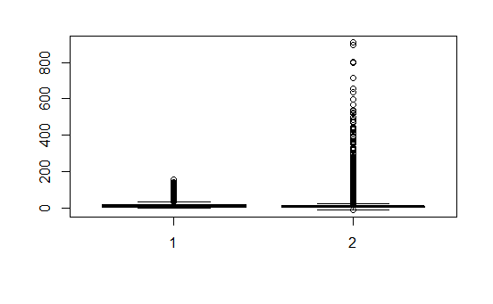

### Fix this boxplot with log

```
NaNs produzidos
```

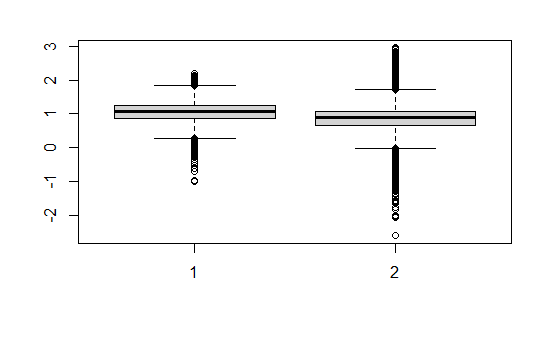

```r
boxplot(log10(x0), log10(x1))
```

### look at strange negative value

```r
negative <- x1 < 0
sum(negative, na.rm = TRUE)
```

```
[1] 26474
```

```r
mean(negative, na.rm= T)
```

```
[1] 0.0215034
```

```r
sum(negative, na.rm= T)
```

```
[1] 26474
```

### read and convert dates

```r
dates <- pm1$Date
str(dates)
```

```
 int [1:1304287] 20120101 20120104 20120107 20120110 20120113 20120116 20120119 20120122 20120125 20120128 ...
```

```r
dates <- as.Date(as.character(dates), "%Y%m%d")
str(dates)
```

```
 Date[1:1304287], format: "2012-01-01" "2012-01-04" "2012-01-07" "2012-01-10" ...
```

[figure not shown]

[figure not shown]

### look at one monitor location in New York State (state.Code == 36)

```r
site0 <- unique(subset(pm0, State.Code == 36,
                       c(County.Code, Site.ID)))
site1 <- unique(subset(pm1, State.Code == 36,
                       c(County.Code, Site.ID)))

#join County.Code and Site.Id into one code
site0 <- paste(site0[,1], site0[,2], sep = ".")
site1 <- paste(site1[,1], site1[,2], sep = ".")
str(site0)
```

```
 chr [1:33] "1.5" "1.12" "5.73" "5.80" "5.83" "5.110" "13.11" ...
```

```r
str(site1)
```

```
 chr [1:18] "1.5" "1.12" "5.80" "5.133" "13.11" "29.5" "31.3" ...
```

### what intercet in 1999 and 2012 in New York State code 36

```r
both <- intersect(site0 , site1)
both
```

```
 [1] "1.5"     "1.12"    "5.80"    "13.11"   "29.5"    "31.3"
 [7] "63.2008" "67.1015" "85.55"   "101.3"
```

put unique code together and subset only New York state code 36

```r
pm0$county.site <- with(pm0, paste(County.Code, Site.ID, sep = "."))
pm1$county.site <- with(pm1, paste(County.Code, Site.ID, sep = "."))

cnt0 <- subset(pm0, State.Code == 36 & county.site %in% both)
cnt1 <- subset(pm1, State.Code == 36 & county.site %in% both)

head(cnt0)
```

|  | X..RD | Action.Code | State.Code | County.Code | Site.ID | Parameter | POC | Sample.Duration | Unit | Method | Date | Start.Time | Sample.Value | Null.Data.Code | Sampling.Frequency | Monitor.Protocol..MP..ID | Qualifier...1 | Qualifier...2 | Qualifier...3 | Qualifier...4 | Qualifier...5 | Qualifier...6 | Qualifier...7 | Qualifier...8 | Qualifier...9 | Qualifier...10 | Alternate.Method.Detectable.Limit | Uncertainty | county.site |
| --- | --- | --- | --- | --- | --- | --- | --- | --- | --- | --- | --- | --- | --- | --- | --- | --- | --- | --- | --- | --- | --- | --- | --- | --- | --- | --- | --- | --- | --- |
| 65873 | RD | I | 36 | 1 | 5 | 88101 | 1 | 7 | 105 | 118 | 19990702 | 00:00 | NA | AQ | 3 | NA | NA | NA | NA | NA | NA | NA | NA | NA | NA | NA | NA | NA | 1.5 |
| 65874 | RD | I | 36 | 1 | 5 | 88101 | 1 | 7 | 105 | 118 | 19990705 | 00:00 | NA | AQ | 3 | NA | NA | NA | NA | NA | NA | NA | NA | NA | NA | NA | NA | NA | 1.5 |
| 65875 | RD | I | 36 | 1 | 5 | 88101 | 1 | 7 | 105 | 118 | 19990708 | 00:00 | NA | AN | 3 | NA | NA | NA | NA | NA | NA | NA | NA | NA | NA | NA | NA | NA | 1.5 |
| 65876 | RD | I | 36 | 1 | 5 | 88101 | 1 | 7 | 105 | 118 | 19990711 | 00:00 | NA | AN | 3 | NA | NA | NA | NA | NA | NA | NA | NA | NA | NA | NA | NA | NA | 1.5 |
| 65877 | RD | I | 36 | 1 | 5 | 88101 | 1 | 7 | 105 | 118 | 19990714 | 00:00 | 11.8 | NA | 3 | NA | NA | NA | NA | NA | NA | NA | NA | NA | NA | NA | NA | NA | 1.5 |
| 65878 | RD | I | 36 | 1 | 5 | 88101 | 1 | 7 | 105 | 118 | 19990717 | 00:00 | 49.4 | NA | 3 | NA | NA | NA | NA | NA | NA | NA | NA | NA | NA | NA | NA | NA | 1.5 |

### count observations per site

```r
sapply(split(cnt0, cnt0$county.site), nrow)
```

```
   1.12     1.5   101.3   13.11    29.5    31.3    5.80 63.2008
     61     122     152      61      61     183      61     122
67.1015   85.55
    122       7
```

```r
sapply(split(cnt1, cnt1$county.site), nrow)
```

```
   1.12     1.5   101.3   13.11    29.5    31.3    5.80 63.2008
     31      64      31      31      33      15      31      30
67.1015   85.55
     31      31
```

```r
pm0sub <- subset(pm0, State.Code == 36 & county.site == 63.2008)
pm1sub <- subset(pm1, State.Code == 36 & county.site == 63.2008)
dim(pm0sub)
```

```
[1] 122  29
```

```r
dim(pm1sub)
```

```
[1] 30 29
```

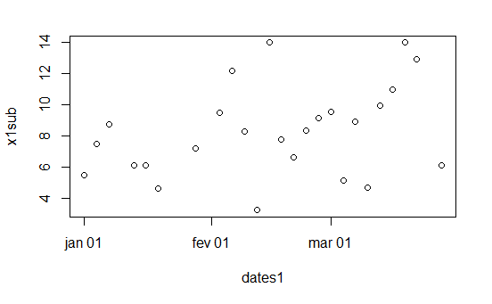

```r
dates1 <- pm1sub$Date
dates1 <- as.Date(as.character(dates1), "%Y%m%d")
x1sub <- pm1sub$Sample.Value
plot(dates1, x1sub)
```

```r
#  I think that we could plot direct
```

**a collect start in july**

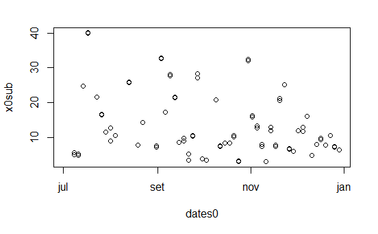

```r
dates0 <- pm0sub$Date
dates0 <- as.Date(as.character(dates0), "%Y%m%d")
x0sub <- pm0sub$Sample.Value
plot(dates0, x0sub)
```

```r
#  I think that we could plot direct
```

## Find global range

```r
rng <- range(x0sub, x1sub, na.rm=T)
par(mfrow = c(1,2), mar = c(4,4,2,1))
plot(dates0,x0sub, pch =20, ylim = rng)
abline( h = median(x0sub, na.rm=T))
```

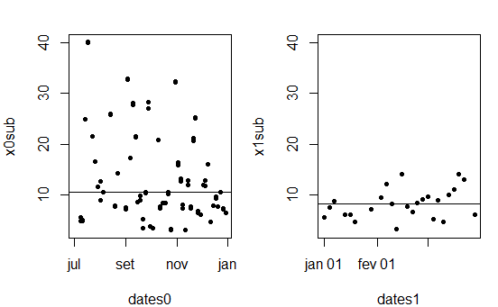

```r
plot(dates1,x1sub, pch =20, ylim = rng)
abline( h = median(x1sub, na.rm=T))
```

### How states improve through years

look at individual states pollution evolution between 1999 and 2012 and how they change

```r
mean0 <- with(pm0, tapply(Sample.Value, State.Code, mean, na.rm = T))
str(mean0)
```

```
 num [1:53(1d)] 19.96 6.67 10.8 15.68 17.66 ...
 - attr(*, "dimnames")=List of 1
  ..$ : chr [1:53] "1" "2" "4" "5" ...
```

```r
summary(mean0)
```

```
   Min. 1st Qu.  Median    Mean 3rd Qu.    Max.
  4.862   9.519  12.315  12.406  15.640  19.956
```

```r
names(mean0)
```

```
 [1] "1"  "2"  "4"  "5"  "6"  "8"  "9"  "10" "11" "12" "13" "15"
[13] "16" "17" "18" "19" "20" "21" "22" "23" "24" "25" "26" "27"
[25] "28" "29" "30" "31" "32" "33" "34" "35" "36" "37" "38" "39"
[37] "40" "41" "42" "44" "45" "46" "47" "48" "49" "50" "51" "53"
[49] "54" "55" "56" "72" "78"
```

```r
mean1 <- with(pm1, tapply(Sample.Value, State.Code, mean, na.rm = T))
str(mean1)
```

```
 num [1:52(1d)] 10.13 4.75 8.61 10.56 9.28 ...
 - attr(*, "dimnames")=List of 1
  ..$ : chr [1:52] "1" "2" "4" "5" ...
```

```r
summary(mean1)
```

```
   Min. 1st Qu.  Median    Mean 3rd Qu.    Max.
  4.006   7.355   8.729   8.759  10.613  11.992
```

```r
names(mean1)
```

```
 [1] "1"  "2"  "4"  "5"  "6"  "8"  "9"  "10" "11" "12" "13" "15"
[13] "16" "17" "18" "19" "20" "21" "22" "23" "24" "25" "26" "27"
[25] "28" "29" "30" "31" "32" "33" "34" "35" "36" "37" "38" "39"
[37] "40" "41" "42" "44" "45" "46" "47" "48" "49" "50" "51" "53"
[49] "54" "55" "56" "72"
```

Separete data frames for State /yeas

|  | state | mean.x | mean.y |
| --- | --- | --- | --- |
| 1 | 1 | 19.956391 | 10.126190 |
| 2 | 10 | 14.492895 | 11.236059 |
| 3 | 11 | 15.786507 | 11.991697 |
| 4 | 12 | 11.137139 | 8.239690 |
| 5 | 13 | 19.943240 | 11.321364 |
| 6 | 15 | 4.861821 | 8.749336 |

Connect Lines

```r
par(mfrow = c(1,1))
with(mrg, plot(rep(1999,52), mrg[,2], xlim = c(1997, 2014)))
with(mrg, points(rep(2012,52), mrg[,3]))
```

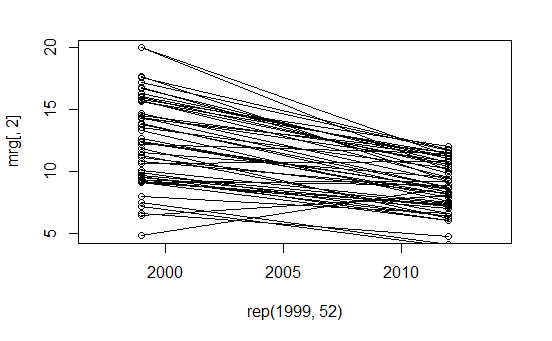

```r
segments(rep(1999,52), mrg[,2], rep(2012,52), mrg[,3])
```